# 412 PROJECT

ELİF YAĞMUR MENTEŞ 2502201

2025-05-08

1. Aim of the Project

In order to anticipate whether a client would sign up for a term deposit (y), this project will investigate, preprocess, analyze, and model the Bank Marketing dataset.

2. Source of the Data and Variables

The dataset comes from a Portuguese bank’s marketing campaign. The dependent variable is:

y: Did the client subscribe to a term deposit? (yes/no)

```r
data <- read.csv("bank-additional-full.csv", sep = ";")
glimpse(data)
```

```
## Rows: 41,188
## Columns: 21
## $ age            <int> 56, 57, 37, 40, 56, 45, 59, 41, 24, 25, 41, 25, 29, 57,…
## $ job            <chr> "housemaid", "services", "services", "admin.", "service…
## $ marital        <chr> "married", "married", "married", "married", "married", …
## $ education      <chr> "basic.4y", "high.school", "high.school", "basic.6y", "…
## $ default        <chr> "no", "unknown", "no", "no", "no", "unknown", "no", "un…
## $ housing        <chr> "no", "no", "yes", "no", "no", "no", "no", "no", "yes",…
## $ loan           <chr> "no", "no", "no", "no", "yes", "no", "no", "no", "no", …
## $ contact        <chr> "telephone", "telephone", "telephone", "telephone", "te…
## $ month          <chr> "may", "may", "may", "may", "may", "may", "may", "may",…
## $ day_of_week    <chr> "mon", "mon", "mon", "mon", "mon", "mon", "mon", "mon",…
## $ duration       <int> 261, 149, 226, 151, 307, 198, 139, 217, 380, 50, 55, 22…
## $ campaign       <int> 1, 1, 1, 1, 1, 1, 1, 1, 1, 1, 1, 1, 1, 1, 1, 1, 1, 1, 1…
## $ pdays          <int> 999, 999, 999, 999, 999, 999, 999, 999, 999, 999, 999, …
## $ previous       <int> 0, 0, 0, 0, 0, 0, 0, 0, 0, 0, 0, 0, 0, 0, 0, 0, 0, 0, 0…
## $ poutcome       <chr> "nonexistent", "nonexistent", "nonexistent", "nonexiste…
## $ emp.var.rate   <dbl> 1.1, 1.1, 1.1, 1.1, 1.1, 1.1, 1.1, 1.1, 1.1, 1.1, 1.1, …
## $ cons.price.idx <dbl> 93.994, 93.994, 93.994, 93.994, 93.994, 93.994, 93.994,…
## $ cons.conf.idx  <dbl> -36.4, -36.4, -36.4, -36.4, -36.4, -36.4, -36.4, -36.4,…
## $ euribor3m      <dbl> 4.857, 4.857, 4.857, 4.857, 4.857, 4.857, 4.857, 4.857,…
## $ nr.employed    <dbl> 5191, 5191, 5191, 5191, 5191, 5191, 5191, 5191, 5191, 5…
## $ y              <chr> "no", "no", "no", "no", "no", "no", "no", "no", "no", "…
```

3. Data Cleaning and Tidying

First, we will verify and fix data types, rename columns if needed, and summarize the fundamental structure.

```r
# Convert character variables to factors
data <- data %>%
  mutate(across(where(is.character), as.factor))

# Check structure and summaries
skim(data)
```

Data summary

| Name | data |
| --- | --- |
| Number of rows | 41188 |
| Number of columns | 21 |
| _______________________ |  |
| Column type frequency: |  |
| factor | 11 |
| numeric | 10 |
| ________________________ |  |
| Group variables | None |

**Variable type: factor**

| skim_variable | n_missing | complete_rate | ordered | n_unique | top_counts |
| --- | --- | --- | --- | --- | --- |
| job | 0 | 1 | FALSE | 12 | adm: 10422, blu: 9254, tec: 6743, ser: 3969 |
| marital | 0 | 1 | FALSE | 4 | mar: 24928, sin: 11568, div: 4612, unk: 80 |
| education | 0 | 1 | FALSE | 8 | uni: 12168, hig: 9515, bas: 6045, pro: 5243 |
| default | 0 | 1 | FALSE | 3 | no: 32588, unk: 8597, yes: 3 |
| housing | 0 | 1 | FALSE | 3 | yes: 21576, no: 18622, unk: 990 |
| loan | 0 | 1 | FALSE | 3 | no: 33950, yes: 6248, unk: 990 |
| contact | 0 | 1 | FALSE | 2 | cel: 26144, tel: 15044 |
| month | 0 | 1 | FALSE | 10 | may: 13769, jul: 7174, aug: 6178, jun: 5318 |
| day_of_week | 0 | 1 | FALSE | 5 | thu: 8623, mon: 8514, wed: 8134, tue: 8090 |
| poutcome | 0 | 1 | FALSE | 3 | non: 35563, fai: 4252, suc: 1373 |
| y | 0 | 1 | FALSE | 2 | no: 36548, yes: 4640 |

**Variable type: numeric**

| skim_variable | n_missing | complete_rate | mean | sd | p0 | p25 | p50 | p75 | p100 | hist |
| --- | --- | --- | --- | --- | --- | --- | --- | --- | --- | --- |
| age | 0 | 1 | 40.02 | 10.42 | 17.00 | 32.00 | 38.00 | 47.00 | 98.00 | ▅▇▃▁▁ |
| duration | 0 | 1 | 258.29 | 259.28 | 0.00 | 102.00 | 180.00 | 319.00 | 4918.00 | ▇▁▁▁▁ |
| campaign | 0 | 1 | 2.57 | 2.77 | 1.00 | 1.00 | 2.00 | 3.00 | 56.00 | ▇▁▁▁▁ |
| pdays | 0 | 1 | 962.48 | 186.91 | 0.00 | 999.00 | 999.00 | 999.00 | 999.00 | ▁▁▁▁▇ |
| previous | 0 | 1 | 0.17 | 0.49 | 0.00 | 0.00 | 0.00 | 0.00 | 7.00 | ▇▁▁▁▁ |
| emp.var.rate | 0 | 1 | 0.08 | 1.57 | -3.40 | -1.80 | 1.10 | 1.40 | 1.40 | ▁▃▁▁▇ |
| cons.price.idx | 0 | 1 | 93.58 | 0.58 | 92.20 | 93.08 | 93.75 | 93.99 | 94.77 | ▁▆▃▇▂ |
| cons.conf.idx | 0 | 1 | -40.50 | 4.63 | -50.80 | -42.70 | -41.80 | -36.40 | -26.90 | ▅▇▁▇▁ |
| euribor3m | 0 | 1 | 3.62 | 1.73 | 0.63 | 1.34 | 4.86 | 4.96 | 5.04 | ▅▁▁▁▇ |
| nr.employed | 0 | 1 | 5167.04 | 72.25 | 4963.60 | 5099.10 | 5191.00 | 5228.10 | 5228.10 | ▁▁▃▁▇ |

4. EDA with Missing Values

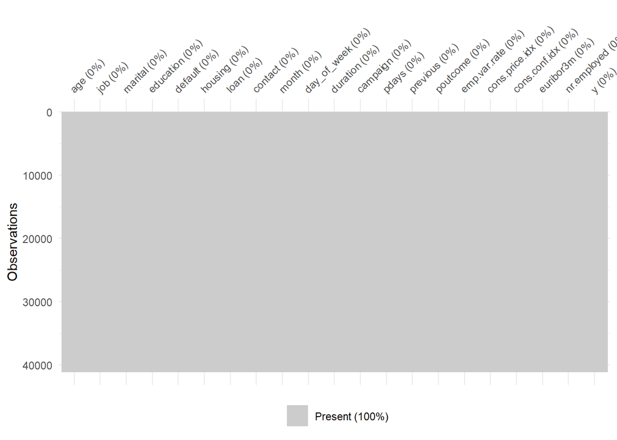

```r
vis_miss(data)
```

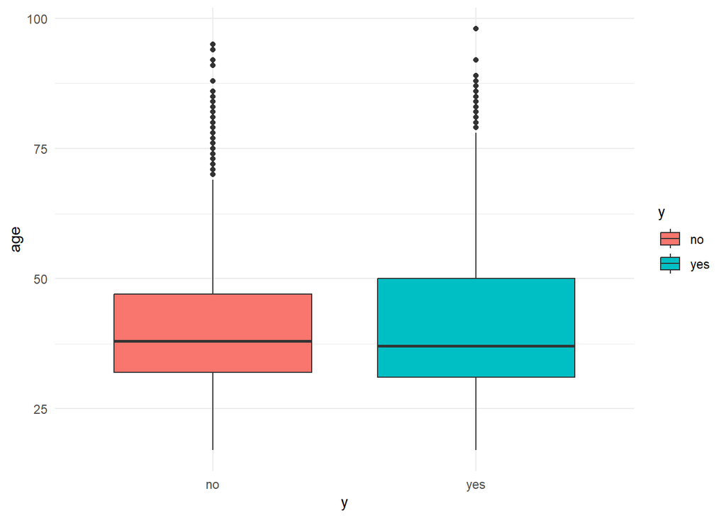

```r
ggplot(data, aes(x = y, y = age, fill = y)) + geom_boxplot() + theme_minimal()
```

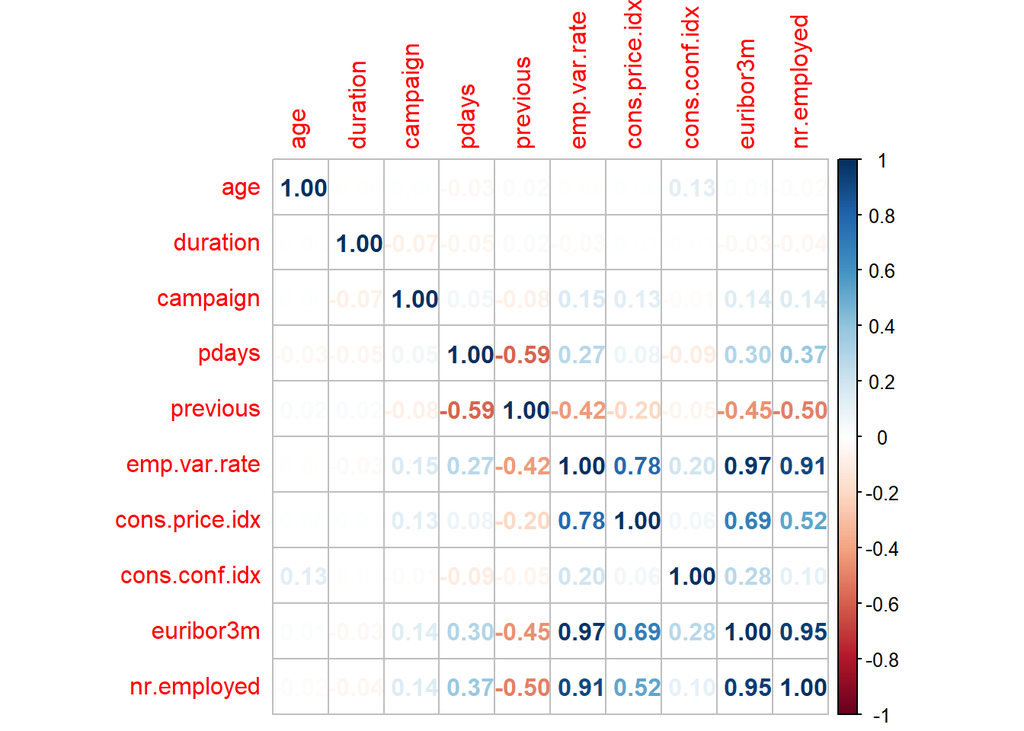

```r
num_data <- select_if(data, is.numeric)
num_data <- num_data[complete.cases(num_data), ]
cor_matrix <- cor(num_data)
corrplot::corrplot(cor_matrix, method = "number")
```

```r
# Summary statistics
summary(data)
```

```
##       age                 job            marital
##  Min.   :17.00   admin.     :10422   divorced: 4612
##  1st Qu.:32.00   blue-collar: 9254   married :24928
##  Median :38.00   technician : 6743   single  :11568
##  Mean   :40.02   services   : 3969   unknown :   80
##  3rd Qu.:47.00   management : 2924
##  Max.   :98.00   retired    : 1720
##                  (Other)    : 6156
##                education        default         housing           loan
##  university.degree  :12168   no     :32588   no     :18622   no     :33950
##  high.school        : 9515   unknown: 8597   unknown:  990   unknown:  990
##  basic.9y           : 6045   yes    :    3   yes    :21576   yes    : 6248
##  professional.course: 5243
##  basic.4y           : 4176
##  basic.6y           : 2292
##  (Other)            : 1749
##       contact          month       day_of_week    duration
##  cellular :26144   may    :13769   fri:7827    Min.   :   0.0
##  telephone:15044   jul    : 7174   mon:8514    1st Qu.: 102.0
##                    aug    : 6178   thu:8623    Median : 180.0
##                    jun    : 5318   tue:8090    Mean   : 258.3
##                    nov    : 4101   wed:8134    3rd Qu.: 319.0
##                    apr    : 2632               Max.   :4918.0
##                    (Other): 2016
##     campaign          pdays          previous            poutcome
##  Min.   : 1.000   Min.   :  0.0   Min.   :0.000   failure    : 4252
##  1st Qu.: 1.000   1st Qu.:999.0   1st Qu.:0.000   nonexistent:35563
##  Median : 2.000   Median :999.0   Median :0.000   success    : 1373
##  Mean   : 2.568   Mean   :962.5   Mean   :0.173
##  3rd Qu.: 3.000   3rd Qu.:999.0   3rd Qu.:0.000
##  Max.   :56.000   Max.   :999.0   Max.   :7.000
##
##   emp.var.rate      cons.price.idx  cons.conf.idx     euribor3m
##  Min.   :-3.40000   Min.   :92.20   Min.   :-50.8   Min.   :0.634
##  1st Qu.:-1.80000   1st Qu.:93.08   1st Qu.:-42.7   1st Qu.:1.344
##  Median : 1.10000   Median :93.75   Median :-41.8   Median :4.857
##  Mean   : 0.08189   Mean   :93.58   Mean   :-40.5   Mean   :3.621
##  3rd Qu.: 1.40000   3rd Qu.:93.99   3rd Qu.:-36.4   3rd Qu.:4.961
##  Max.   : 1.40000   Max.   :94.77   Max.   :-26.9   Max.   :5.045
##
##   nr.employed     y
##  Min.   :4964   no :36548
##  1st Qu.:5099   yes: 4640
##  Median :5191
##  Mean   :5167
##  3rd Qu.:5228
##  Max.   :5228
##
```

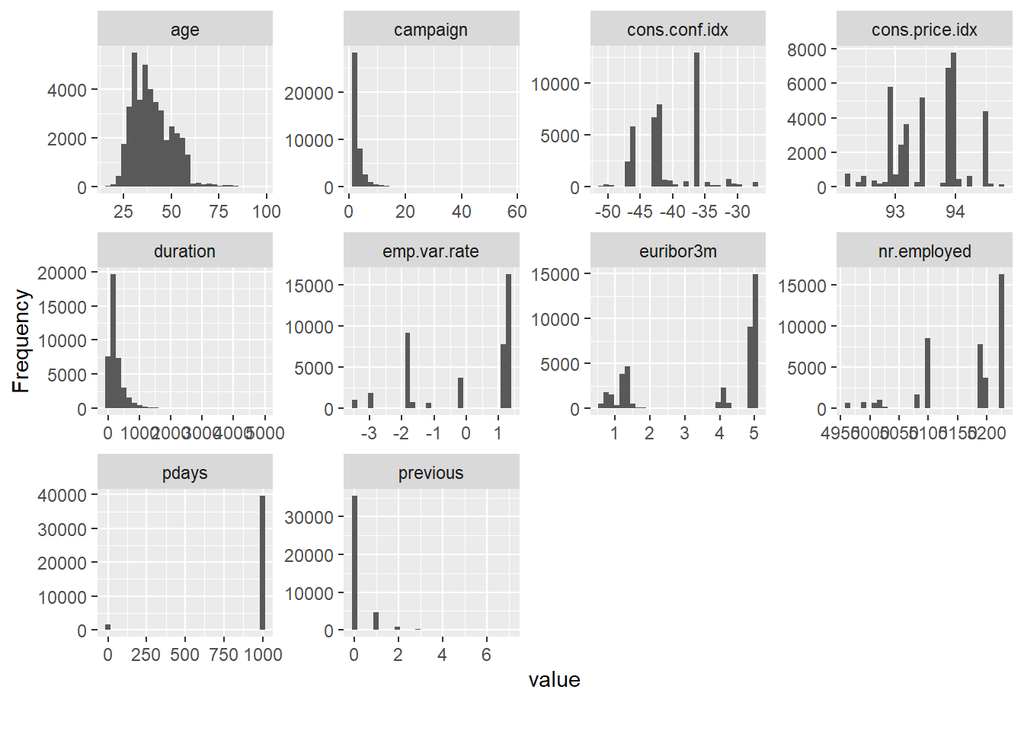

```r
# Histograms for numeric variables
plot_histogram(data)
```

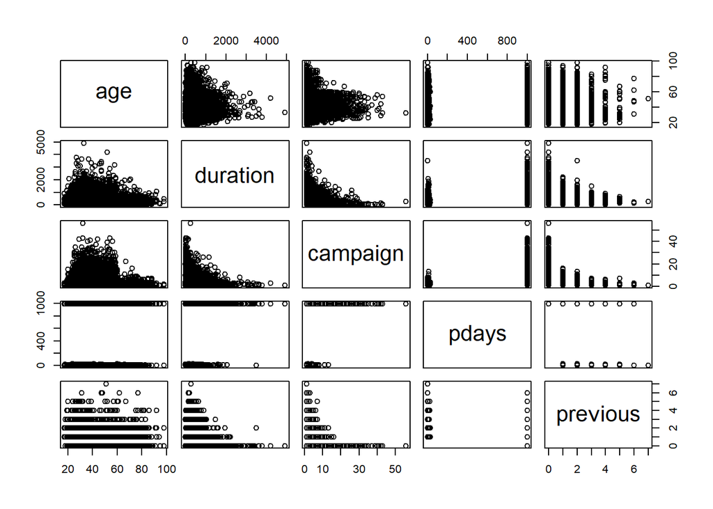

```r
# Matrix scatter plot
pairs(select(num_data, age, duration, campaign, pdays, previous), pch = 21)
```

5. Missing Data Mechanism and Imputation

```r
data$pdays <- ifelse(data$pdays == 999, NA, data$pdays)
data$pdays[is.na(data$pdays)] <- median(data$pdays, na.rm = TRUE)
```

6. Feature Engineering

New variables such as contacted_before, a binary indication of prior interaction, will be created.

```r
data <- data %>% mutate(contacted_before = ifelse(previous > 0, "yes", "no"),
                        contacted_before = as.factor(contacted_before))
```

7. Confirmatory Data Analysis

We will evaluate whether there is a substantial age difference between subscribers and non-subscribers.

```r
shapiro.test(sample(data$age, 5000))  # Shapiro for normality
```

```
##
##  Shapiro-Wilk normality test
##
## data:  sample(data$age, 5000)
## W = 0.95671, p-value < 2.2e-16
```

```r
t.test(age ~ y, data = data)
```

```
##
##  Welch Two Sample t-test
##
## data:  age by y
## t = -4.7795, df = 5258.5, p-value = 1.805e-06
## alternative hypothesis: true difference in means between group no and group yes is not equal to 0
## 95 percent confidence interval:
##  -1.4129336 -0.5909889
## sample estimates:
##  mean in group no mean in group yes
##          39.91119          40.91315
```

```r
set.seed(412)
train_index <- sample(seq_len(nrow(data)), size = 0.7 * nrow(data))
train <- data[train_index, ]
test <- data[-train_index, ]
```

9. Statistical Modeling (Logistic Regression)

```r
# Use logistic regression
model <- glm(y ~ . -duration, data = train, family = "binomial")

summary(model)
```

```
##
## Call:
## glm(formula = y ~ . - duration, family = "binomial", data = train)
##
## Deviance Residuals:
##     Min       1Q   Median       3Q      Max
## -2.1258  -0.3967  -0.3204  -0.2637   2.9879
##
## Coefficients: (2 not defined because of singularities)
##                                Estimate Std. Error z value Pr(>|z|)
## (Intercept)                  -2.610e+02  3.973e+01  -6.569 5.06e-11 ***
## age                          -2.906e-03  2.531e-03  -1.148 0.250976
## jobblue-collar               -1.487e-01  8.151e-02  -1.825 0.068076 .
## jobentrepreneur              -1.466e-01  1.309e-01  -1.120 0.262856
## jobhousemaid                 -3.529e-02  1.533e-01  -0.230 0.818010
## jobmanagement                -2.824e-02  8.950e-02  -0.316 0.752339
## jobretired                    3.190e-01  1.119e-01   2.850 0.004370 **
## jobself-employed             -4.660e-03  1.201e-01  -0.039 0.969057
## jobservices                  -2.871e-02  8.782e-02  -0.327 0.743785
## jobstudent                    2.186e-01  1.215e-01   1.799 0.071942 .
## jobtechnician                -1.584e-02  7.406e-02  -0.214 0.830621
## jobunemployed                -1.590e-01  1.360e-01  -1.169 0.242483
## jobunknown                    8.025e-02  2.509e-01   0.320 0.749104
## maritalmarried                1.161e-02  7.124e-02   0.163 0.870493
## maritalsingle                 5.935e-02  8.116e-02   0.731 0.464584
## maritalunknown               -2.342e-01  4.920e-01  -0.476 0.634037
## educationbasic.6y            -1.769e-03  1.246e-01  -0.014 0.988669
## educationbasic.9y            -3.621e-03  9.652e-02  -0.038 0.970074
## educationhigh.school         -1.248e-02  9.454e-02  -0.132 0.894978
## educationilliterate           1.121e+00  6.818e-01   1.644 0.100158
## educationprofessional.course -2.719e-02  1.049e-01  -0.259 0.795416
## educationuniversity.degree    6.729e-02  9.517e-02   0.707 0.479509
## educationunknown              2.083e-02  1.258e-01   0.166 0.868483
## defaultunknown               -2.478e-01  6.814e-02  -3.637 0.000276 ***
## defaultyes                   -8.484e+00  1.388e+02  -0.061 0.951258
## housingunknown               -1.821e-01  1.461e-01  -1.246 0.212626
## housingyes                   -4.476e-02  4.285e-02  -1.044 0.296254
## loanunknown                          NA         NA      NA       NA
## loanyes                      -1.760e-02  5.931e-02  -0.297 0.766715
## contacttelephone             -7.216e-01  7.956e-02  -9.071  < 2e-16 ***
```

[output cut: 19 more lines]

```
## cons.price.idx                2.282e+00  2.623e-01   8.703  < 2e-16 ***
## cons.conf.idx                 3.146e-02  8.298e-03   3.791 0.000150 ***
## euribor3m                     2.132e-01  1.359e-01   1.569 0.116657
## nr.employed                   8.849e-03  3.227e-03   2.742 0.006111 **
## contacted_beforeyes                  NA         NA      NA       NA
## ---
## Signif. codes:  0 '***' 0.001 '**' 0.01 '*' 0.05 '.' 0.1 ' ' 1
##
## (Dispersion parameter for binomial family taken to be 1)
##
##     Null deviance: 20464  on 28830  degrees of freedom
## Residual deviance: 16024  on 28779  degrees of freedom
## AIC: 16128
##
## Number of Fisher Scoring iterations: 10
```

```r
train <- train %>% select(-duration)  # drop duration

# Fit initial model
full_model <- glm(y ~ ., data = train, family = "binomial")

# Extract the names of estimated (non-aliased) coefficients
estimated_coefs <- names(coef(full_model))
estimated_coefs <- estimated_coefs[estimated_coefs != "(Intercept)"]

# Clean variable names to match dataset
estimated_vars <- gsub("`", "", unique(gsub("^.*\\$", "", estimated_coefs)))
estimated_vars <- intersect(names(train), estimated_vars)  # keep only real columns

# Build safe formula
if (length(estimated_vars) > 0) {
  formula_text <- paste("y ~", paste(estimated_vars, collapse = " + "))
  clean_model <- glm(as.formula(formula_text), data = train, family = "binomial")

  # VIF calculation
  library(car)
  print(vif(clean_model))

} else {
  message("⚠️ No usable predictors remained. Check data preprocessing steps.")
}
```

```
##            age       campaign          pdays       previous   emp.var.rate
##       1.029739       1.027185       1.015590       1.289716      31.666263
## cons.price.idx  cons.conf.idx      euribor3m    nr.employed
##      10.426956       2.977952      58.911120      35.061160
```

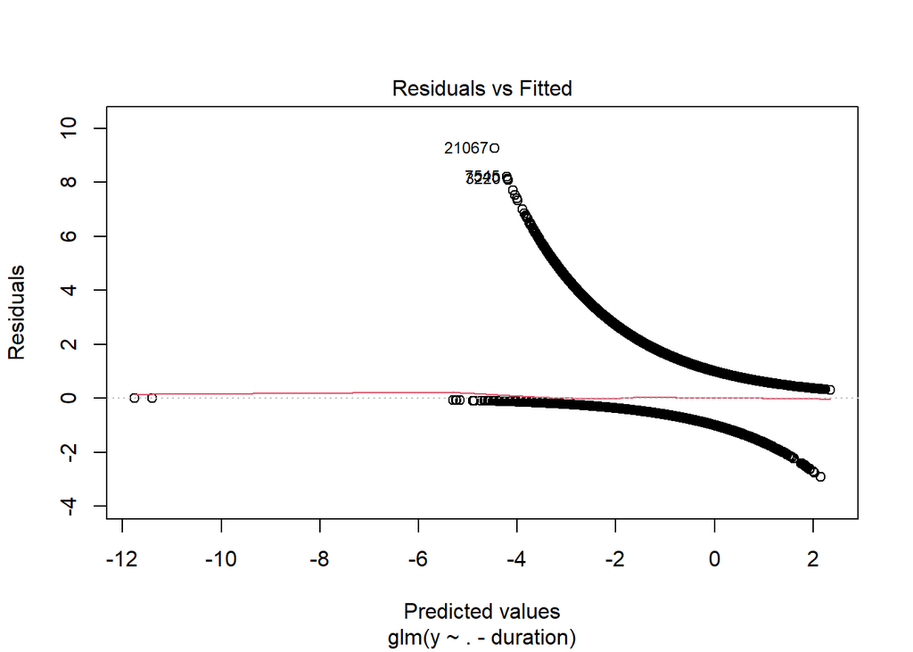

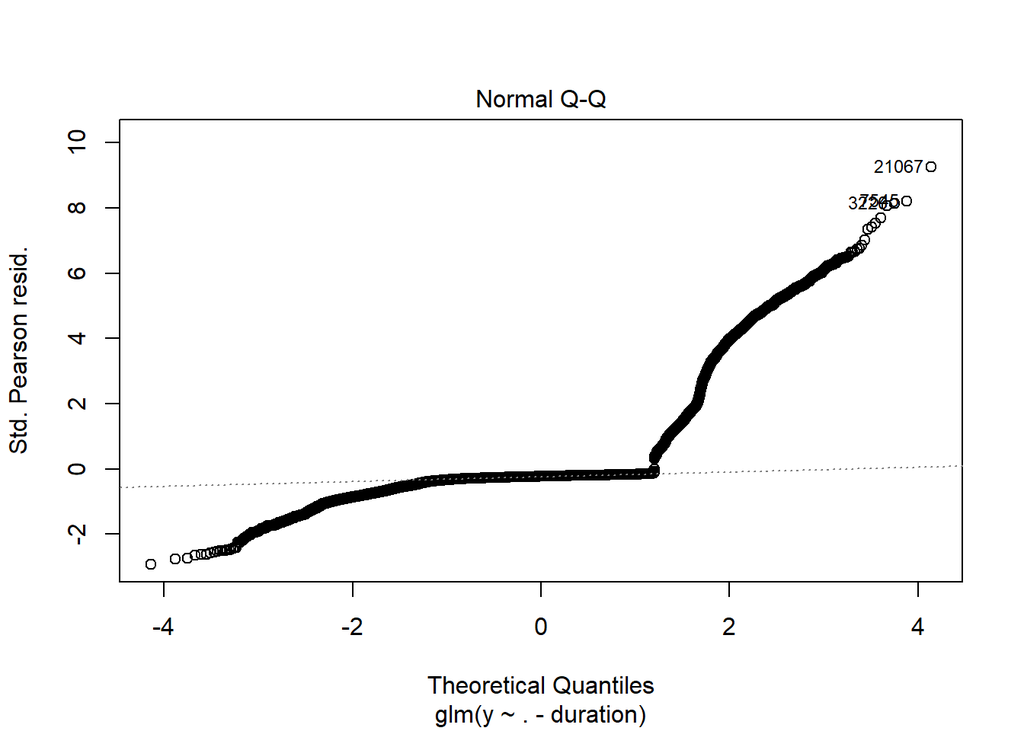

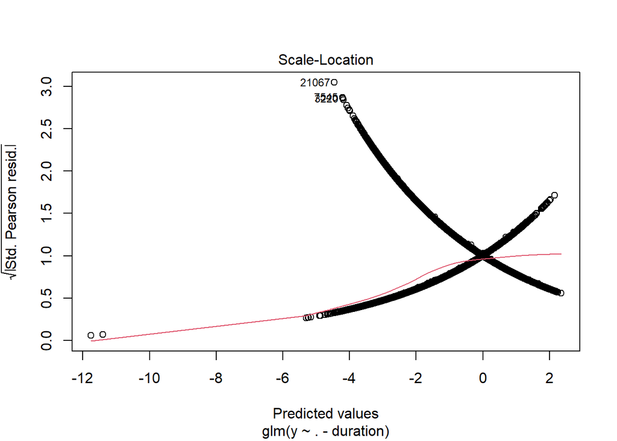

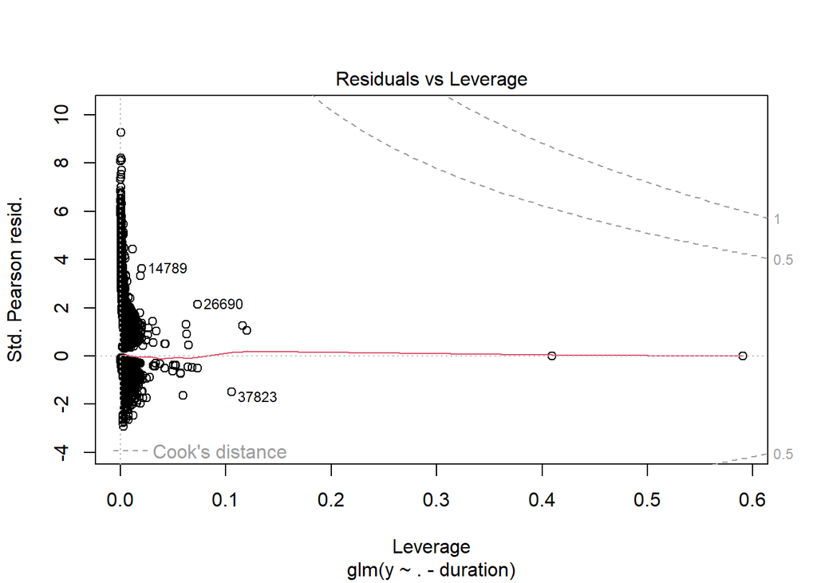

```r
# Residuals plot
plot(model)
```

```r
# Predict on test data
prob <- predict(clean_model, newdata = test, type = "response")
pred <- ifelse(prob > 0.5, "yes", "no") %>% as.factor()

# Predict on train data (fix)
train_prob <- predict(clean_model, newdata = train, type = "response")
train_class <- ifelse(train_prob > 0.5, "yes", "no") %>% as.factor()

# Confusion matrices
table(Predicted = pred, Actual = test$y)
```

```
##          Actual
## Predicted    no   yes
##       no  10901  1185
##       yes   104   167
```

```r
table(Predicted = train_class, Actual = train$y)
```

```
##          Actual
## Predicted    no   yes
##       no  25298  2934
##       yes   245   354
```

```r
# Accuracy
mean(pred == test$y)
```

```
## [1] 0.8956867
```

```r
mean(train_class == train$y)
```

```
## [1] 0.8897367
```

```r
# Evaluation function
evaluate_model <- function(predictions, actuals) {
  cm <- table(Predicted = predictions, Actual = actuals)
  accuracy <- sum(diag(cm)) / sum(cm)
  list(ConfusionMatrix = cm, Accuracy = accuracy)
}

evaluate_model(pred, test$y)
```

```
## $ConfusionMatrix
##          Actual
## Predicted    no   yes
##       no  10901  1185
##       yes   104   167
##
## $Accuracy
## [1] 0.8956867
```

```r
evaluate_model(train_class, train$y)
```

```
## $ConfusionMatrix
##          Actual
## Predicted    no   yes
##       no  25298  2934
##       yes   245   354
##
## $Accuracy
## [1] 0.8897367
```

The logistic regression model yielded reasonably good results with an accuracy of about 89.6% on the test data and 88.9% on the training data. The close alignment between the training and test accuracies indicates that the model is able to generalize effectively and isn’t experiencing overfitting.

However an analysis of the confusion matrix uncovers a notable class imbalance. The count of clients who opted for a term deposit (y = yes) is significantly lower than those who didn’t (y = no). Although the model accurately predicted most instances of “no,” it faced challenges with “yes” predictions, missing a considerable number of actual subscribers.

This implies that even though the model demonstrates overall accuracy, it shows a bias towards the majority class which may not be suitable if the aim is to maximize the identification of potential subscribers. Future approaches could include the use of balanced sampling, cost sensitive learning or exploring different models such as decision trees or ensemble methods to enhance the prediction of the minority class.

An early investigation, preprocessing, and modeling of the bank marketing dataset were reported in this interim report. We constructed a logistic regression model and verified its performance and underlying assumptions. Future research will examine other models (such as random forests or decision trees), enhance feature selection, and optimize performance through hyperparameter tweaking.